# Introduction to Machine Learning

Examples of concrete Machine Learning tasks:

- Predict the price of a house
  - features = characteristics of the houses
  - target = sale price
- Recognise a number on an image
  - features = each pixel of the image
  - target = number
- Find recurring themes in a corpus of text
  - features = texts
  - target = ? (this is an unsupervised task)

## Supervised Learning

- The data is labeled (we know the answers)
- Objective: predict the target

## Unsupervised Learning

- The data does not have labels
- Objective: Find underlying patterns in the data

## Focus Supervised Learning

Two types of main tasks:

### Regression:

- Predict a **continuous** value
- Eg: Predict someone's revenue

### Classification:

- Predict a **category**
- Eg: Predict dog or cat

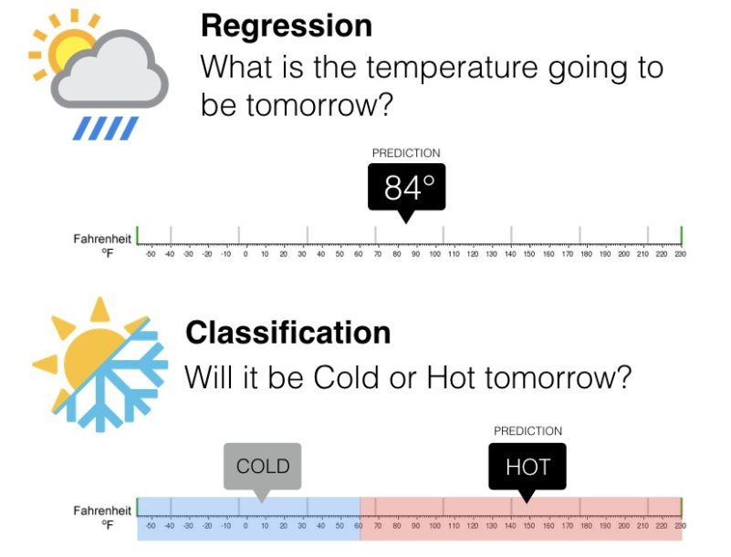

Credit: Daniel Vieira, [Vector Field Neural Networks](https://www.researchgate.net/figure/Example-of-classification-and-regression-problem-when-dealing-with-temperature_fig7_333221048)

## Data Preparation Steps

- Transform the raw data to make them exploitable:
  - **One Hot Encoding**: transform a categorical feature into binary columns -> Machine Learning models do not know how to interpret strings
  - **Scaling the Data**: transform the numerical features so they are in the same scale -> Machine Learning models converge better if the features are in the same scale, we do not want certain features to bias our model

## Typical steps of a Supervised Machine Learning Project

1. Data cleaning
2. Selection of features (which features are really important to predict the target ?)
3. Preparation of the data (encoding and scaling)
4. Separation of `X` (features) and `y` (target)
5. Separation of `X_train` and `y_train` (train set) and `X_test` and `y_test` (test set, typically 20-30% of the data)
6. Choice of the model
7. Model training on the train set
8. Evaluation of the model on the test set

### Why do we evaluate the models ?

The problem with **overfitting**

- A model can learn by heart the patterns of the training data
- In this case, it can not generalise on unseen data
- **Solution**: Test the model on a separate set of data (test set) which the model has not been trained on